# HW5 Part 1-3

Colm Kennedy

2022-11-05

# Imports

```r
library(ggplot2)
library(dplyr)
library(moderndive)
library(knitr)
library(skimr)
```

# Import and clean data, set seed

```r
movie <- read.csv('C:/Users/colm_/RProjects/Stat-291-HW5/Data/movie_boxoffice.csv')
set.seed(2468)
nrow(movie)
```

```
## [1] 4969
```

```r
movie <- distinct(movie)
nrow(movie)
```

```
## [1] 4869
```

### 0. How many duplicated records were removed from boxoffice data? What is your random seed number?

100 duplicated records were removed from boxoffice data. We originally had 4,969 observations, we now have 4,869. Our random seed number is 2468.

# Part I

### 1. Treat the box office data as your population. Have a histogram of the global box office earning. Describe the shape of the distribution

The histogram of global box office earnings appears to have heavy right skew. The most frequent box office earning, by far is in the $0 - $50M bin. The skew is apparent in the statistics as well, the mean is $95.8M, which is much higher than the median of $31.2M, further suggesting a high degree of right skew. As for variablity, the standard devation is $177.5M, and the interquartile range is $96.6M. The full range is $2,783.9M. The distribution does not appear normal

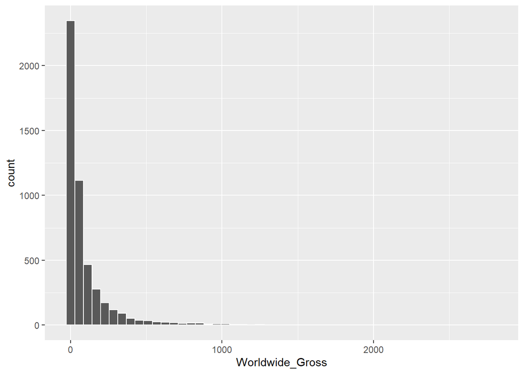

```r
ggplot(data = movie, mapping = aes(x = Worldwide_Gross)) +
  geom_histogram(color = 'white', bins = 50)
```

```r
summary(movie$Worldwide_Gross)
```

```
##     Min.  1st Qu.   Median     Mean  3rd Qu.     Max.
##    0.000    5.778   31.152   95.832  102.333 2783.919
```

```r
sd(movie$Worldwide_Gross)
```

```
## [1] 177.4594
```

```r
IQR(movie$Worldwide_Gross)
```

```
## [1] 96.5545
```

### 2. In the population, what is the average global box office earning? What is the standard deviation? What is the proportion of movies whose global box office earning exceeds budget?

The average global box office earning in the population is: $95.8M. The standard deviation is: $177.5M. The proportion of movies whose global box office earning exceeds budget is 3146/4869, or 0.646.

```r
moviesOverBudget <- subset(movie, (movie$Worldwide_Gross - movie$Budget) > 0)
nrow(moviesOverBudget)
```

```
## [1] 3146
```

```r
propOverBudg <- nrow(moviesOverBudget) / nrow(movie)
propOverBudg
```

```
## [1] 0.6461286
```